# Amazon prime user

```python
import pandas as pd
import numpy as np
import matplotlib.pyplot as plt
import seaborn as sns
```

```python
data = pd.read_csv(r"C:\Users\hp\Downloads\amazon_prime_users.csv")
```

```python
data.head(2)
```

|  | User ID | Name | Email Address | Username | Date of Birth | Gender | Location | Membership Start Date | Membership End Date | Subscription Plan | Payment Information | Renewal Status | Usage Frequency | Purchase History | Favorite Genres | Devices Used | Engagement Metrics | Feedback/Ratings | Customer Support Interactions |
| --- | --- | --- | --- | --- | --- | --- | --- | --- | --- | --- | --- | --- | --- | --- | --- | --- | --- | --- | --- |
| 0 | 1 | Ronald Murphy | williamholland@example.com | williamholland | 1953-06-03 | Male | Rebeccachester | 2024-01-15 | 2025-01-14 | Annual | Mastercard | Manual | Regular | Electronics | Documentary | Smart TV | Medium | 3.6 | 3 |
| 1 | 2 | Scott Allen | scott22@example.org | scott22 | 1978-07-08 | Male | Mcphersonview | 2024-01-07 | 2025-01-06 | Monthly | Visa | Manual | Regular | Electronics | Horror | Smartphone | Medium | 3.8 | 7 |

```python
data
```

|  | User ID | Name | Email Address | Username | Date of Birth | Gender | Location | Membership Start Date | Membership End Date | Subscription Plan | Payment Information | Renewal Status | Usage Frequency | Purchase History | Favorite Genres | Devices Used | Engagement Metrics | Feedback/Ratings | Customer Support Interactions |
| --- | --- | --- | --- | --- | --- | --- | --- | --- | --- | --- | --- | --- | --- | --- | --- | --- | --- | --- | --- |
| 0 | 1 | Ronald Murphy | williamholland@example.com | williamholland | 1953-06-03 | Male | Rebeccachester | 2024-01-15 | 2025-01-14 | Annual | Mastercard | Manual | Regular | Electronics | Documentary | Smart TV | Medium | 3.6 | 3 |
| 1 | 2 | Scott Allen | scott22@example.org | scott22 | 1978-07-08 | Male | Mcphersonview | 2024-01-07 | 2025-01-06 | Monthly | Visa | Manual | Regular | Electronics | Horror | Smartphone | Medium | 3.8 | 7 |
| 2 | 3 | Jonathan Parrish | brooke16@example.org | brooke16 | 1994-12-06 | Female | Youngfort | 2024-04-13 | 2025-04-13 | Monthly | Mastercard | Manual | Regular | Books | Comedy | Smart TV | Low | 3.3 | 8 |
| 3 | 4 | Megan Williams | elizabeth31@example.net | elizabeth31 | 1964-12-22 | Female | Feliciashire | 2024-01-24 | 2025-01-23 | Monthly | Amex | Auto-renew | Regular | Electronics | Documentary | Smart TV | High | 3.3 | 7 |
| 4 | 5 | Kathryn Brown | pattersonalexandra@example.org | pattersonalexandra | 1961-06-04 | Male | Port Deborah | 2024-02-14 | 2025-02-13 | Annual | Visa | Auto-renew | Frequent | Clothing | Drama | Smart TV | Low | 4.3 | 1 |
| ... | ... | ... | ... | ... | ... | ... | ... | ... | ... | ... | ... | ... | ... | ... | ... | ... | ... | ... | ... |
| 2495 | 2496 | Michael Lopez | williamsroberto@example.org | williamsroberto | 1967-08-19 | Male | Smithport | 2024-01-25 | 2025-01-24 | Annual | Visa | Auto-renew | Frequent | Electronics | Comedy | Smartphone | Medium | 4.9 | 2 |
| 2496 | 2497 | Matthew Woodard | lkaiser@example.com | lkaiser | 1980-10-23 | Male | Ethanport | 2024-03-03 | 2025-03-03 | Annual | Amex | Manual | Frequent | Books | Comedy | Smart TV | Medium | 4.0 | 0 |
| 2497 | 2498 | Morgan Barnes | erikaholland@example.net | erikaholland | 1972-03-31 | Female | Alexandraborough | 2024-02-09 | 2025-02-08 | Annual | Visa | Manual | Frequent | Electronics | Documentary | Tablet | Low | 4.9 | 8 |
| 2498 | 2499 | Gina Castaneda | reedcourtney@example.net | reedcourtney | 1965-08-02 | Female | Williammouth | 2024-02-18 | 2025-02-17 | Monthly | Visa | Manual | Regular | Clothing | Comedy | Smartphone | High | 3.4 | 7 |
| 2499 | 2500 | Mark Nicholson | martinisaac@example.net | martinisaac | 1972-11-13 | Female | Estradaborough | 2024-01-28 | 2025-01-27 | Annual | Visa | Auto-renew | Regular | Books | Documentary | Smart TV | High | 3.3 | 9 |

2500 rows × 19 columns

```python
data.isnull().sum()
```

```
User ID                          0
Name                             0
Email Address                    0
Username                         0
Date of Birth                    0
Gender                           0
Location                         0
Membership Start Date            0
Membership End Date              0
Subscription Plan                0
Payment Information              0
Renewal Status                   0
Usage Frequency                  0
Purchase History                 0
Favorite Genres                  0
Devices Used                     0
Engagement Metrics               0
Feedback/Ratings                 0
Customer Support Interactions    0
dtype: int64
```

```python
data.shape
```

```
(2500, 19)
```

```python
data.info()
```

```
<class 'pandas.core.frame.DataFrame'>
RangeIndex: 2500 entries, 0 to 2499
Data columns (total 19 columns):
 #   Column                         Non-Null Count  Dtype
---  ------                         --------------  -----
 0   User ID                        2500 non-null   int64
 1   Name                           2500 non-null   object
 2   Email Address                  2500 non-null   object
 3   Username                       2500 non-null   object
 4   Date of Birth                  2500 non-null   object
 5   Gender                         2500 non-null   object
 6   Location                       2500 non-null   object
 7   Membership Start Date          2500 non-null   object
 8   Membership End Date            2500 non-null   object
 9   Subscription Plan              2500 non-null   object
 10  Payment Information            2500 non-null   object
 11  Renewal Status                 2500 non-null   object
 12  Usage Frequency                2500 non-null   object
 13  Purchase History               2500 non-null   object
 14  Favorite Genres                2500 non-null   object
 15  Devices Used                   2500 non-null   object
 16  Engagement Metrics             2500 non-null   object
 17  Feedback/Ratings               2500 non-null   float64
 18  Customer Support Interactions  2500 non-null   int64
dtypes: float64(1), int64(2), object(16)
memory usage: 371.2+ KB
```

```python
data.columns
```

```
Index(['User ID', 'Name', 'Email Address', 'Username', 'Date of Birth',
       'Gender', 'Location', 'Membership Start Date', 'Membership End Date',
       'Subscription Plan', 'Payment Information', 'Renewal Status',
       'Usage Frequency', 'Purchase History', 'Favorite Genres',
       'Devices Used', 'Engagement Metrics', 'Feedback/Ratings',
       'Customer Support Interactions'],
      dtype='object')
```

```python
data["User ID"].count()
```

```
2500
```

```python
data[["Gender"]].value_counts()
```

```
Gender
Male      1260
Female    1240
Name: count, dtype: int64
```

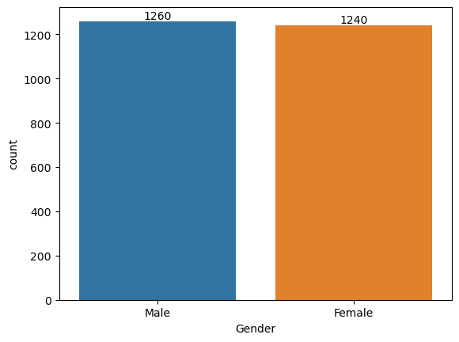

```python
ax=sns.countplot(x="Gender", data=data)
ax.bar_label(ax.containers[0]);
```

# Subscription Plan

```python
data["Subscription Plan"].value_counts()
```

```
Subscription Plan
Annual     1271
Monthly    1229
Name: count, dtype: int64
```

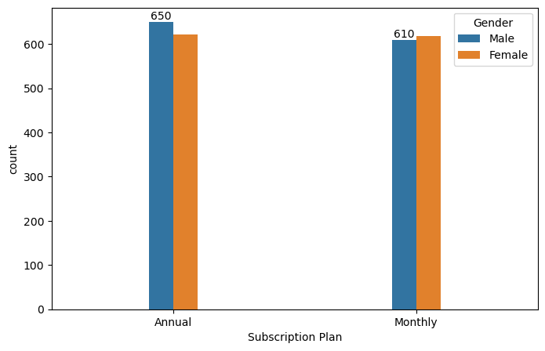

```python
plt.figure(figsize=(8,5))
ax=sns.countplot(x="Subscription Plan", data=data, hue = 'Gender',width=0.2, )
ax.bar_label(ax.containers[0]);
```

As per above analysis using countplot, it is observed that most of the people chose annual sbbscription plan of amazon prime because annual subcription plan was resonable than monthly pack.

# Payment Information

```python
data["Payment Information"].value_counts()
```

```
Payment Information
Mastercard    856
Visa          838
Amex          806
Name: count, dtype: int64
```

```python
x=data["Payment Information"].value_counts().index
```

```python
y=data["Payment Information"].value_counts().values
```

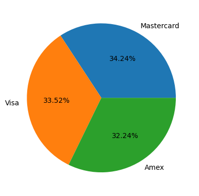

```python
plt.pie(y, data=data,labels=x, autopct='%0.2f%%');
```

As per above analysis using pieplot, it is observed that people use three type of payment mode like Mastercard, Amex, and Visa. As per analysis most of the people chose Mastercard for payment mode i.e.34.24%.

# Rennewal Status

```python
data["Renewal Status"].value_counts()
```

```
Renewal Status
Auto-renew    1274
Manual        1226
Name: count, dtype: int64
```

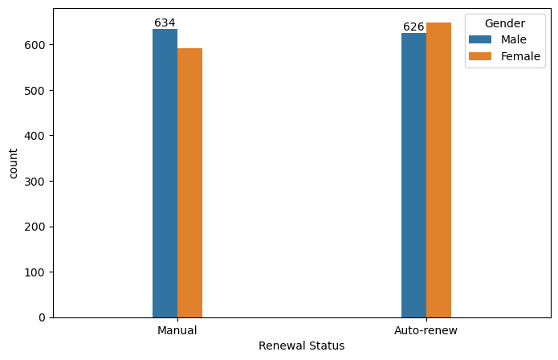

```python
plt.figure(figsize=(8,5))
ax=sns.countplot(x='Renewal Status', data=data,orient='h',hue='Gender',width=0.2)
ax.bar_label(ax.containers[0]);
```

As per above analysis using countplot, it is observed that people use two type of Renewal mode like Manual and Auto-renew. As per analysis most of the people chose Auto-renew for Renewal mode i.e.1274.

# Favorite Genres

```python
data["Favorite Genres"].value_counts()
```

```
Favorite Genres
Horror         383
Action         380
Romance        368
Drama          361
Comedy         349
Documentary    340
Sci-Fi         319
Name: count, dtype: int64
```

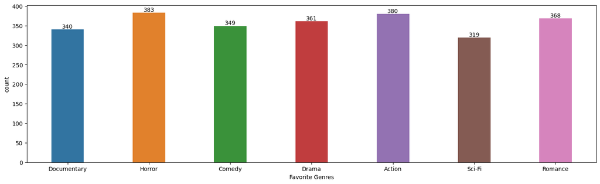

```python
plt.figure(figsize=(18,5))
ax=sns.countplot(x='Favorite Genres', data=data,orient='h',width=0.4)
ax.bar_label(ax.containers[0]);
```

As per above analysis using countplot, it was observed that Horror was favorite Genres of the people i.e. 15% approx.

# Devices Used

```python
data["Devices Used"].value_counts()
```

```
Devices Used
Smartphone    867
Tablet        853
Smart TV      780
Name: count, dtype: int64
```

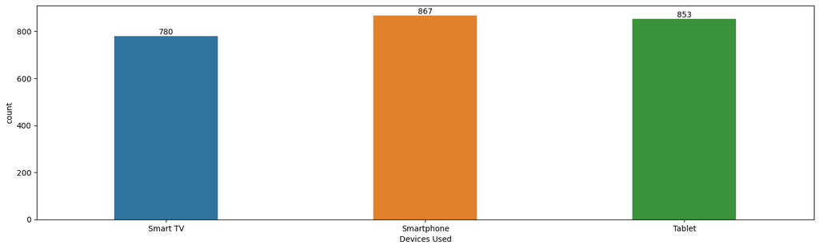

```python
plt.figure(figsize=(18,5))
ax=sns.countplot(x='Devices Used', data=data,orient='h',width=0.4)
ax.bar_label(ax.containers[0]);
```

As per above analysis using countplot, it was observed that people used their smartphone device (34.68%)for amazon prime service.

# Purchase History

```python
data["Purchase History"].value_counts()
```

```
Purchase History
Books          851
Electronics    847
Clothing       802
Name: count, dtype: int64
```

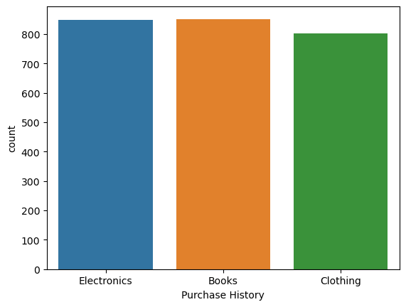

```python
sns.countplot(x="Purchase History",data=data);
```

As per above analysis, It was observed that people use the benefit of Amazon prime user membership for purchasing the different category of product like Electronics, Books, Clothing. As per purched history books sales was more than the other two catogory.

# Usage Frequency

```python
data["Usage Frequency"].value_counts()
```

```
Usage Frequency
Frequent      851
Regular       827
Occasional    822
Name: count, dtype: int64
```

```python
data["Usage Frequency"].value_counts()/data['User ID'].count()*100
```

```
Usage Frequency
Frequent      34.04
Regular       33.08
Occasional    32.88
Name: count, dtype: float64
```

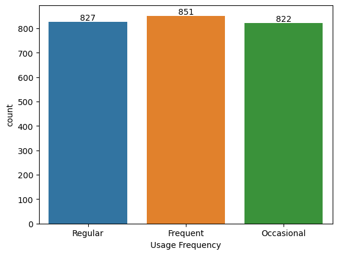

```python
ax=sns.countplot(x="Usage Frequency",data=data)
ax.bar_label(ax.containers[0]);
```

As per above analysis, 34.04% Frequent people use the amazon prime.. 33.08% Regular people use the amazon prime. 32.88% Occasional people use the amazon prime.